# Heart Failure Prediction

Alex Hetherington

05/11/2021

# 1 Load in Dataset

This dataset contains 12 columns, with the last column being the predictive column - whether or not the patient has heart disease.

- Age: age of the patient [years]
- Sex: sex of the patient [M: Male, F: Female]
- ChestPainType: chest pain type [TA: Typical Angina, ATA: Atypical Angina, NAP: Non-Anginal Pain, ASY: Asymptomatic]
- RestingBP: resting blood pressure [mm Hg]
- Cholesterol: serum cholesterol [mm/dl]
- FastingBS: fasting blood sugar [1: if FastingBS > 120 mg/dl, 0: otherwise]
- RestingECG: resting electrocardiogram results [Normal: Normal, ST: having ST-T wave abnormality (T wave inversions and/or ST elevation or depression of > 0.05 mV),LVH: showing probable or definite left ventricular hypertrophy by Estes’ criteria]
- MaxHR: maximum heart rate achieved [Numeric value between 60 and 202]
- ExerciseAngina: exercise-induced angina [Y: Yes, N: No]
- Oldpeak: oldpeak = ST [Numeric value measured in depression]
- ST_Slope: the slope of the peak exercise ST segment [Up: upsloping, Flat: flat, Down: downsloping]
- HeartDisease: output class [1: heart disease, 0: Normal]

```r
# Loading in data, recoding factor levels and assigning correct column data types.

setwd("~/Documents/Heart Failure Prediction")
data <- as_tibble(data.frame(read.csv('heart.csv')))
data$HeartDisease <- recode(as.factor(data$HeartDisease),'0' = 'Negative','1' = 'Positive')
data$FastingBS <- recode(as.factor(data$FastingBS),'0' = 'Normal','1' = 'High')
data$Sex <- recode(as.factor(data$Sex),"M" = "Male","F" = "Female")
data$ChestPainType <- as.factor(data$ChestPainType)
data$RestingECG <- relevel(as.factor(data$RestingECG),2)
data$ExerciseAngina <- recode(as.factor(data$ExerciseAngina),"N" = "No","Y" = "Yes")
data$ST_Slope <- as.factor(data$ST_Slope)



numeric_data = select_if(data,is.numeric)
print(paste("# Missing Values :" , sum(is.na(data))))
```

```
## [1] "# Missing Values : 0"
```

# 2 EDA (Exploratory Data Analysis)

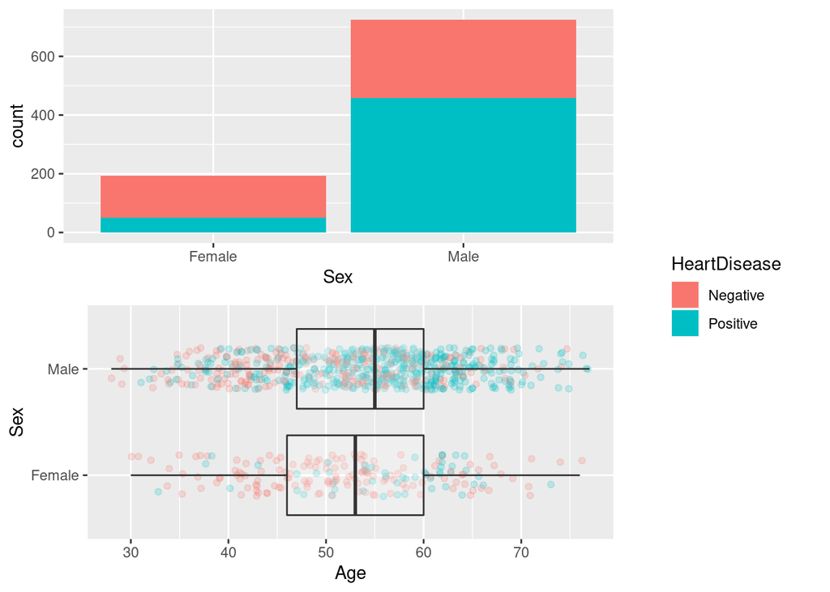

```r
## Initial demographic plots of gender and age.
p1 <- ggplot(data = data,aes(x = Sex)) + geom_bar(aes(fill = HeartDisease))
p2 <- ggplot(data = data,aes(x = Age,y = Sex)) + geom_jitter(aes(color = HeartDisease),height = 0.2,alpha = 0.2) + geom_boxplot(alpha = 0.2)
p_grid <- plot_grid(p1 + theme(legend.position = "none"),
                    p2 + theme(legend.position = "none"),
                    ncol = 1)
legend_obj <- get_legend(p1)
plot_grid(p_grid,legend_obj,rel_widths = c(1.5,.5))
```

Without accurate knowledge of the general population and the prevalence of independent variables the nomenclature/practice of odds and odds ratios should be used rather than risk and risk ratios.

```r
## Chi Squared test of independence
gend_tab <- table(data$Sex,data$HeartDisease)
chisq.test(gend_tab,correct = FALSE)
```

```
##
##  Pearson's Chi-squared test
##
## data:  gend_tab
## X-squared = 85.646, df = 1, p-value < 2.2e-16
```

```r
oddsratio(gend_tab,method = "wald")$measure
```

```
##         odds ratio with 95% C.I.
##          estimate    lower    upper
##   Female 1.000000       NA       NA
##   Male   4.905918 3.437758 7.001083
```

With a very small p-value in the Chi-squared test, we crudely conclude that there is a significant correlation between gender and heart disease. Also we derive a crude estimate with 95% confidence that your odds of heart disease are increase by 391% for men compared to women.

## 2.1 Continuous Variables

Taking just the numeric data, a matrix of scatter plots and correlations is drawn.

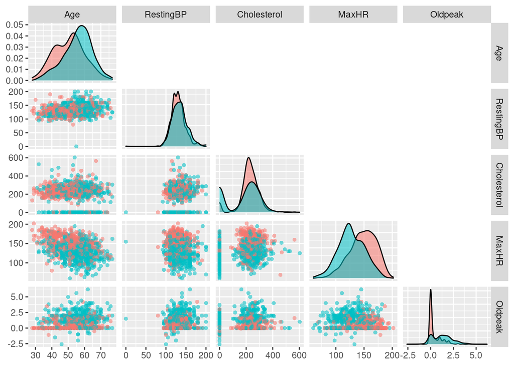

```r
temp = numeric_data
temp$HeartDisease = data$HeartDisease
ggpairs(temp,columns = 1:5,ggplot2::aes(colour = HeartDisease,alpha = 0.3,shape = '.'),upper = NULL)
```

Not much can be clearly seen from this; much of the data is clustered together and hard to see correlations. The diagonal plots the distribution of each factor coloured by heart disease. From this we see that those who have heart disease are generally older and have a lower maximum heart rate.

Of particular note is a noticeable density of near 0 cholesterol levels. There is also a single observation of a 0 RestingBP, and so this datum is removed.

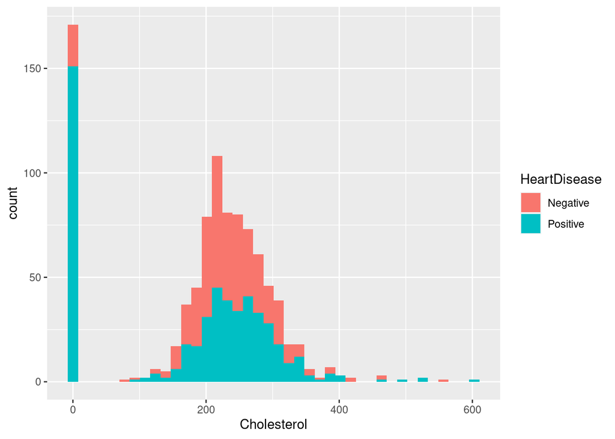

```r
## Remove "RestingBP = 0" datum
data <- data[data$RestingBP != 0,]
temp <- numeric_data <- select_if(data,is.numeric)

## Plot histogram for cholesterol
ggplot(data = data,aes(x = Cholesterol,fill = HeartDisease)) + geom_histogram(bins = 40)
```

These observations could be reasonably omitted and removed from the data, however instead they will be itself the subject of prediction for precursive model that can interpolate more appropriate cholesterol values.

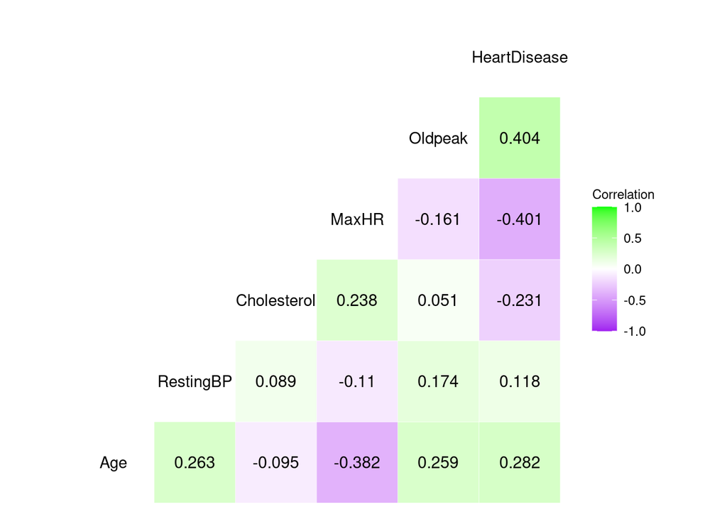

```r
temp$HeartDisease = as.numeric(data$HeartDisease)
ggcorr(temp,method = "pairwise",label = TRUE,label_round = 3,low = "Purple",mid = "White",high = "Green",name = "Correlation")
```

The largest magnitude correlation (among independent variables) is between Age and MaxHR, with a slight negative correlation (-0.382). Resting blood pressure appears not to correlate strongly with any other continuous variable nor heart disease.

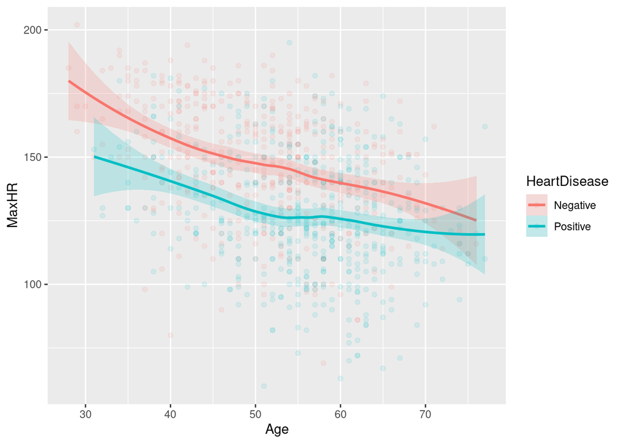

```r
ggplot(data = data,aes(x = Age,y = MaxHR,colour = HeartDisease)) + geom_point(alpha = 0.1) + geom_smooth(aes(fill = HeartDisease),alpha = 0.2)
```

```r
faraway::vif(numeric_data)
```

```
##         Age   RestingBP Cholesterol       MaxHR     Oldpeak
##    1.290633    1.103014    1.084216    1.241029    1.098714
```

Plotting Age against MaxHR we see the trend is seen clearly. The older you are, the lower your maximum heart rate, which is as expected with a large decrease in the amount of exercise older people tend to do. Across all ages, a lower maximum heart rate is associated with an increased rate of Heart Disease. With a quick look at the variance inflation factor we see no immediate cause for concern over collinearity between continuous variables.

## 2.2 Categorical Variables

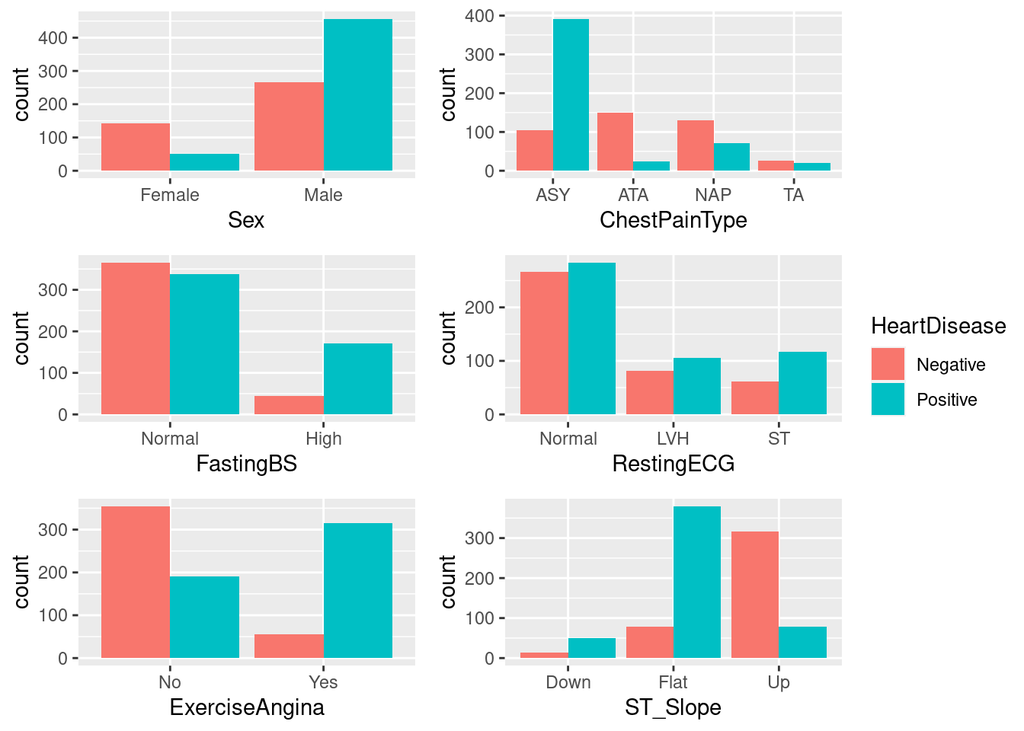

```r
## Create Each plot in turn
p1 <- ggplot(data = data,aes(x = Sex)) + geom_bar(aes(fill = HeartDisease),stat = "count",position = "dodge")
p2 <- ggplot(data = data,aes(x = ChestPainType)) + geom_bar(aes(fill = HeartDisease),stat = "count",position = "dodge")
p3 <- ggplot(data = data,aes(x = FastingBS)) + geom_bar(aes(fill = HeartDisease),stat = "count",position = "dodge")
p4 <- ggplot(data = data,aes(x = RestingECG)) + geom_bar(aes(fill = HeartDisease),stat = "count",position = "dodge")
p5 <- ggplot(data = data,aes(x = ExerciseAngina)) + geom_bar(aes(fill = HeartDisease),stat = "count",position = "dodge")
p6 <- ggplot(data = data,aes(x = ST_Slope)) + geom_bar(aes(fill = HeartDisease),stat = "count",position = "dodge")

## Align into a grid, remove individual legends
p_grid <- plot_grid(p1 + theme(legend.position = "none"),
          p2 + theme(legend.position = "none"),
          p3 + theme(legend.position = "none"),
          p4 + theme(legend.position = "none"),
          p5 + theme(legend.position = "none"),
          p6 + theme(legend.position = "none"),
          ncol = 2)
legend_obj <- get_legend(p1)
## Display
plot_grid(p_grid,legend_obj,rel_widths = c(3,.6))
```

```r
## ~ Exercise Angina OR
temp <- table(data$ExerciseAngina,data$HeartDisease)
print('Exercise Angina')
```

```
## [1] "Exercise Angina"
```

```r
oddsratio(temp)$measure[-1,]
```

```
##  estimate     lower     upper
## 10.627077  7.644486 14.995695
```

```r
## ~ ST_Slope OR
##Combine Down and Flat into one level to compare with Up
temp_ST_Slope <- data$ST_Slope
levels(temp_ST_Slope) <- c('Down/Flat','Down/Flat','Up')
temp <- table(temp_ST_Slope,data$HeartDisease)
print('ST Slope')
```

```
## [1] "ST Slope"
```

```r
oddsratio(temp,rev = 'rows')$measure[-1,]
```

```
## estimate    lower    upper
## 18.63525 13.41392 26.18785
```

RestingECG has no clear trend difference between the levels, whilst ChestPainType does have good variation between levels however curiously has the asymptomatic group having the highest correlation with heart disease. In other words, for this data you are more likely to have heart disease if you don’t have chest pain, and having chest pain may indicate that you don’t have heart disease! This is most likely as a result of the bias introduced from the procurement of the dataset; most of the data is made up of positive cases of heart disease and those with high risk factors and possible indicators, one such being chest pain.

**The presence of ChestPainType in a real-world model would knowingly directly cause incorrect prediction behavior for those outside of this biased sample, and therefore should be reasonably omitted from prediction.** Although don’t do so in this work as it isn’t meant for the real world.

## 2.3 Cholesterol Prediction

```r
## Separate data and remove HeartDisease
x_pred = data[data$Cholesterol == 0,-12]
x_train = data[data$Cholesterol != 0,-12]

## Implementing backwards stepwise regression
lmod = lm(Cholesterol ~ .,data = x_train)
lmod = step(lmod,direction = 'backward',trace = 0)
summary(lmod)
```

```
##
## Call:
## lm(formula = Cholesterol ~ Sex + ChestPainType + RestingBP +
##     RestingECG + ST_Slope, data = x_train)
##
## Residuals:
##     Min      1Q  Median      3Q     Max
## -148.86  -37.60   -4.98   31.09  354.84
##
## Coefficients:
##                  Estimate Std. Error t value Pr(>|t|)
## (Intercept)      214.4424    20.2252  10.603  < 2e-16 ***
## SexMale          -17.3276     5.0626  -3.423 0.000654 ***
## ChestPainTypeATA  -3.1790     6.0940  -0.522 0.602064
## ChestPainTypeNAP -11.8412     5.6353  -2.101 0.035956 *
## ChestPainTypeTA  -18.3740     9.6315  -1.908 0.056820 .
## RestingBP          0.3126     0.1252   2.497 0.012750 *
## RestingECGLVH      9.4948     5.2473   1.809 0.070786 .
## RestingECGST      -4.2380     5.9378  -0.714 0.475625
## ST_SlopeFlat      10.4018     9.4394   1.102 0.270841
## ST_SlopeUp        -0.7738     9.7771  -0.079 0.936943
## ---
## Signif. codes:  0 '***' 0.001 '**' 0.01 '*' 0.05 '.' 0.1 ' ' 1
##
## Residual standard error: 58.07 on 736 degrees of freedom
## Multiple R-squared:  0.04788,    Adjusted R-squared:  0.03624
## F-statistic: 4.112 on 9 and 736 DF,  p-value: 3.535e-05
```

```r
print(paste("Datum 150 :: Predicted",predict(lmod,x_train[150,])," - True",x_train$Cholesterol[150]))
```

```
## [1] "Datum 150 :: Predicted 248.160584224351  - True 603"
```

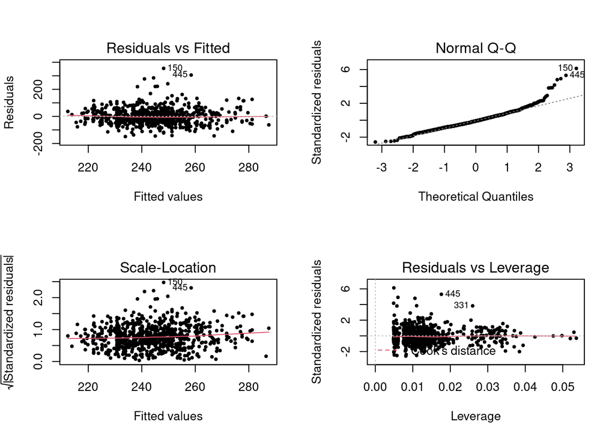

```r
par(mfrow = c(2,2))
plot(lmod,cex = 0.5,pch = 19,id.n = 2)
```

The residuals are evenly distributed around across the fitted values, which indicates a desired linear relationship. The Q-Q plot shows that the residuals of the errors are reasonably normal around most of the data, however is higher for those with extremely high cholesterol. Looking at individual number 150, their real cholesterol level is 603 [mm/dl], which is drastically larger than the predicted 248.2 [mm/dl]. The scale-location validates the homoscedasticity assumption (the variance of the residuals is even across fitted values). No points in particular have very large leverage and error, with no points residing outside of cook’s distance.

With a very small R-Squared, and high residual standard error we see that the data is still spread very wide around the fitted model. Predictions are likely to be off, even though we don’t know the true values anyway, as values in the real world are much more varied. As a result of predicting these values for cholesterol, the data will be more normalized to the generic cholesterol distribution.

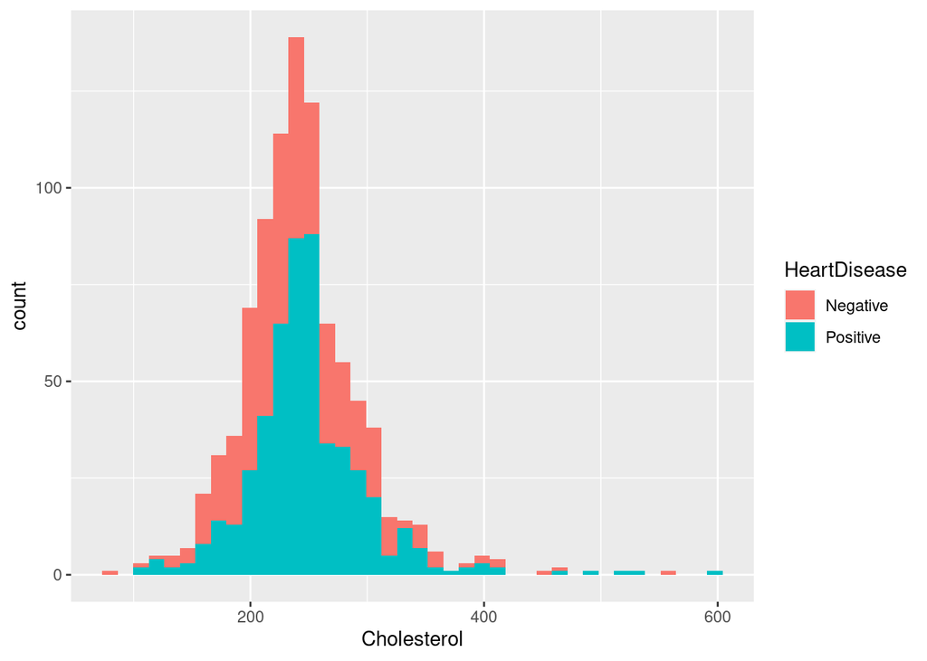

```r
## Using for predictions
data$Cholesterol[data$Cholesterol == 0] <- predict(lmod,x_pred)
numeric_data = select_if(data,is.numeric)
ggplot(data = data,aes(x = Cholesterol,fill = HeartDisease)) + geom_histogram(bins = 40)
```

## PCA

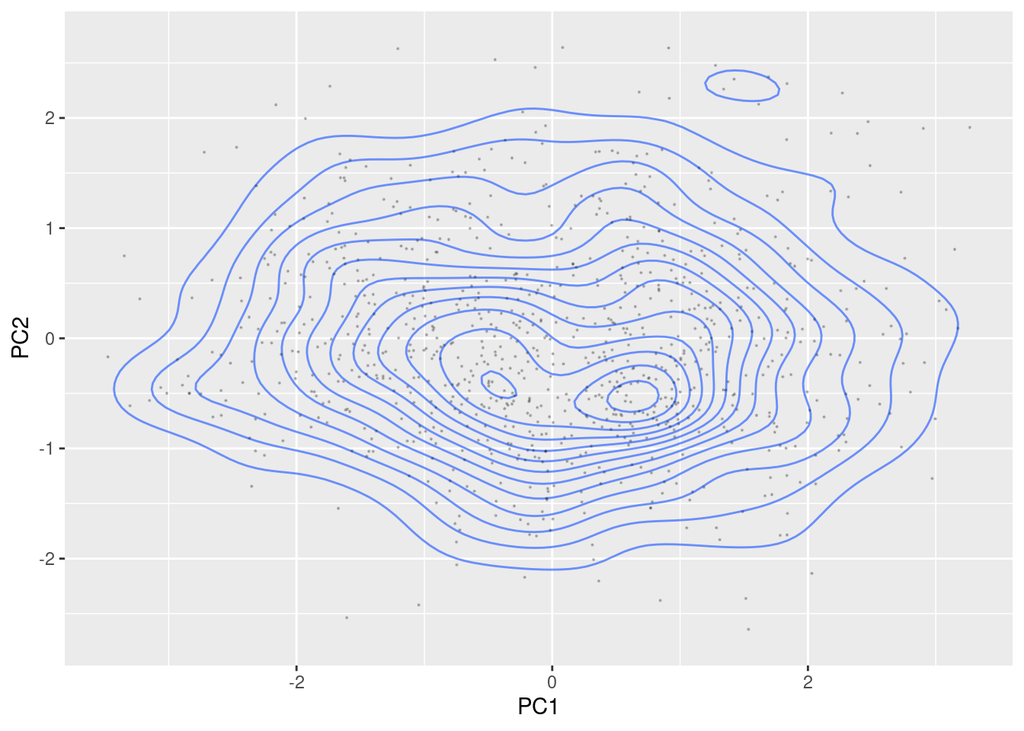

```r
pr <-as.data.frame(prcomp(numeric_data,scale = TRUE)$x)
pr$HeartDisease <- data$HeartDisease
pr$ExerciseAngina <- data$ExerciseAngina
pr$Sex <- data$Sex
pr$FastingBS <- data$FastingBS
pr$FastingBS <- data$FastingBS
p1 <- ggplot(pr,aes(x = PC1,PC2)) + geom_density_2d(alpha = 0.7) + geom_point(alpha = 0.2,size = 0.1) + ylim(-2.7,2.7) + scale_color_distiller(palette="Set1")
p2<- ggplot(pr,aes(x = PC1,PC2,colour = HeartDisease)) + geom_density_2d(alpha = 0.7) + geom_point(alpha = 0.2,size = 0.1) + ylim(-2.7,2.7)
p3 <- ggplot(pr,aes(x = PC1,PC2,colour = ExerciseAngina)) + geom_density_2d(alpha = 0.7) + geom_point(alpha = 0.2,size = 0.1) + ylim(-2.7,2.7) + scale_color_brewer(palette="Set1")
p4 <- ggplot(pr,aes(x = PC1,PC2,colour = Sex)) + geom_density_2d(alpha = 0.7) + geom_point(alpha = 0.2,size = 0.1) + ylim(-2.7,2.7) + scale_color_brewer(palette="Set1")
p5 <- ggplot(pr,aes(x = PC1,PC2,colour = FastingBS)) + geom_density_2d(alpha = 0.7) + geom_point(alpha = 0.2,size = 0.1) + ylim(-2.7,2.7) + scale_color_brewer(palette="Set1")
p1
```

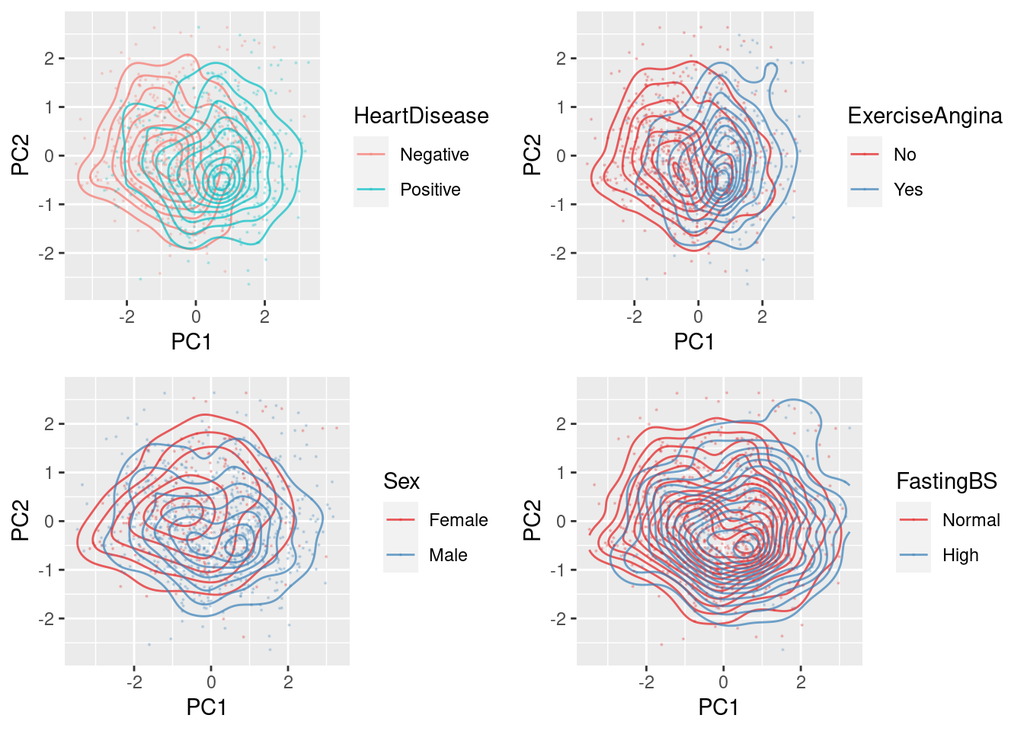

```r
plot_grid(p2,p3,p4,p5)
```

The Overall PCA plot shows two epicenters of the data, roughly separated across the first principal component axis. Coding contours by some categorical variables we see that there is some separation in epicenters of each binary level however there is much overlap. Overall, the clear separation of negative and positive contours in the HeartDisease plot show some ability to predict positive and negative cases with only 2 numeric variables, and adding even more explanatory variables will only improve predictions.

# 3 Logistic model

With a binary response variable, this data can be fitted using a generalized linear model, using the binomial distribution as the distribution of the errors and the logit (log-odds) link function. This means that the coefficients in the model are the increase in the log of the odds of heart disease resulting from a 1-unit increase in that factor.

Initially, all factors are considered when predicting heart disease. The intercept corresponds to an individual who is/has:

- 21, Female, No chest pain, RestingBP of 80 [mm Hg], Cholesterol of 100 [mm/dl], Low FastingBS, normal RestingECG, MaxHR of 50bpm, No ExeciseAngina, Oldpeak of 0 and Down ST_Slope.

## 3.1 Full Model

```r
## With binomial response, tecnhically the correct family would be the bernoulli family with the logit link function,
## However the binomial is used as bernoulli is not in base R, and is the same for this data as bernoulli.
lmod_full =  glm(formula = HeartDisease ~ I(Age-21) + Sex + ChestPainType + I(RestingBP-80) + I(Cholesterol - 100) + FastingBS + RestingECG + I((MaxHR - 50)/50) + ExerciseAngina + Oldpeak + ST_Slope,data = data,family = binomial(link = "logit"))
summary(lmod_full)
```

```
##
## Call:
## glm(formula = HeartDisease ~ I(Age - 21) + Sex + ChestPainType +
##     I(RestingBP - 80) + I(Cholesterol - 100) + FastingBS + RestingECG +
##     I((MaxHR - 50)/50) + ExerciseAngina + Oldpeak + ST_Slope,
##     family = binomial(link = "logit"), data = data)
##
## Deviance Residuals:
##     Min       1Q   Median       3Q      Max
## -2.8589  -0.3873   0.1865   0.4792   2.6389
##
## Coefficients:
##                       Estimate Std. Error z value Pr(>|z|)
## (Intercept)          -1.619897   0.905087  -1.790 0.073491 .
## I(Age - 21)           0.018754   0.013116   1.430 0.152760
## SexMale               1.624431   0.278827   5.826 5.68e-09 ***
## ChestPainTypeATA     -1.899651   0.323701  -5.869 4.40e-09 ***
## ChestPainTypeNAP     -1.619562   0.259585  -6.239 4.40e-10 ***
## ChestPainTypeTA      -1.445163   0.429265  -3.367 0.000761 ***
## I(RestingBP - 80)     0.001810   0.006182   0.293 0.769643
## I(Cholesterol - 100)  0.002252   0.002024   1.113 0.265795
## FastingBSHigh         1.340371   0.266749   5.025 5.04e-07 ***
## RestingECGLVH        -0.006404   0.267470  -0.024 0.980899
## RestingECGST         -0.006779   0.290590  -0.023 0.981389
## I((MaxHR - 50)/50)   -0.389568   0.244716  -1.592 0.111403
## ExerciseAnginaYes     0.857228   0.240654   3.562 0.000368 ***
## Oldpeak               0.360109   0.115583   3.116 0.001836 **
## ST_SlopeFlat          1.225280   0.426681   2.872 0.004083 **
## ST_SlopeUp           -1.103790   0.445024  -2.480 0.013127 *
## ---
## Signif. codes:  0 '***' 0.001 '**' 0.01 '*' 0.05 '.' 0.1 ' ' 1
##
## (Dispersion parameter for binomial family taken to be 1)
##
##     Null deviance: 1260.95  on 916  degrees of freedom
## Residual deviance:  606.68  on 901  degrees of freedom
## AIC: 638.68
##
## Number of Fisher Scoring iterations: 5
```

From the summary output, we see that ResitingBP has a very high p-value, as does RestingECG. RestingBP and RestingECG were both singled out earlier as not correlating well with heart disease, and so are removed first from the model.

### 3.1.1 Step 1

```r
lmod1 = glm(formula = HeartDisease ~ I(Age-21) + Sex + ChestPainType + I(Cholesterol - 100) + FastingBS + I((MaxHR - 50)/50) + ExerciseAngina + Oldpeak + ST_Slope,data = data,family = binomial(link = "logit"))
summary(lmod1)
```

```
##
## Call:
## glm(formula = HeartDisease ~ I(Age - 21) + Sex + ChestPainType +
##     I(Cholesterol - 100) + FastingBS + I((MaxHR - 50)/50) + ExerciseAngina +
##     Oldpeak + ST_Slope, family = binomial(link = "logit"), data = data)
##
## Deviance Residuals:
##     Min       1Q   Median       3Q      Max
## -2.8446  -0.3846   0.1843   0.4740   2.6516
##
## Coefficients:
##                       Estimate Std. Error z value Pr(>|z|)
## (Intercept)          -1.578587   0.885041  -1.784 0.074484 .
## I(Age - 21)           0.019470   0.012422   1.567 0.117023
## SexMale               1.622152   0.277436   5.847 5.01e-09 ***
## ChestPainTypeATA     -1.892969   0.322338  -5.873 4.29e-09 ***
## ChestPainTypeNAP     -1.617051   0.259402  -6.234 4.55e-10 ***
## ChestPainTypeTA      -1.433659   0.426644  -3.360 0.000779 ***
## I(Cholesterol - 100)  0.002314   0.002001   1.156 0.247590
## FastingBSHigh         1.339510   0.265244   5.050 4.42e-07 ***
## I((MaxHR - 50)/50)   -0.389595   0.238168  -1.636 0.101882
## ExerciseAnginaYes     0.865154   0.238498   3.628 0.000286 ***
## Oldpeak               0.362921   0.114913   3.158 0.001587 **
## ST_SlopeFlat          1.236685   0.425051   2.909 0.003620 **
## ST_SlopeUp           -1.090539   0.442983  -2.462 0.013824 *
## ---
## Signif. codes:  0 '***' 0.001 '**' 0.01 '*' 0.05 '.' 0.1 ' ' 1
##
## (Dispersion parameter for binomial family taken to be 1)
##
##     Null deviance: 1260.95  on 916  degrees of freedom
## Residual deviance:  606.77  on 904  degrees of freedom
## AIC: 632.77
##
## Number of Fisher Scoring iterations: 5
```

```r
drop1(lmod1)
```

```
## Single term deletions
##
## Model:
## HeartDisease ~ I(Age - 21) + Sex + ChestPainType + I(Cholesterol -
##     100) + FastingBS + I((MaxHR - 50)/50) + ExerciseAngina +
##     Oldpeak + ST_Slope
##                      Df Deviance    AIC
## <none>                    606.77 632.77
## I(Age - 21)           1   609.23 633.23
## Sex                   1   643.84 667.84
## ChestPainType         3   669.43 689.43
## I(Cholesterol - 100)  1   608.12 632.12
## FastingBS             1   634.55 658.55
## I((MaxHR - 50)/50)    1   609.45 633.45
## ExerciseAngina        1   619.87 643.87
## Oldpeak               1   617.03 641.03
## ST_Slope              2   714.07 736.07
```

### 3.1.2 Step 2

```r
lmod2 = glm(formula = HeartDisease ~ I(Age-21) + Sex + ChestPainType + FastingBS + I((MaxHR - 50)/50) + ExerciseAngina + Oldpeak + ST_Slope,data = data,family = binomial(link = "logit"))
summary(lmod2)
```

```
##
## Call:
## glm(formula = HeartDisease ~ I(Age - 21) + Sex + ChestPainType +
##     FastingBS + I((MaxHR - 50)/50) + ExerciseAngina + Oldpeak +
##     ST_Slope, family = binomial(link = "logit"), data = data)
##
## Deviance Residuals:
##     Min       1Q   Median       3Q      Max
## -2.7830  -0.3852   0.1867   0.4788   2.6541
##
## Coefficients:
##                    Estimate Std. Error z value Pr(>|z|)
## (Intercept)        -1.25291    0.83663  -1.498 0.134243
## I(Age - 21)         0.01955    0.01242   1.575 0.115280
## SexMale             1.57299    0.27334   5.755 8.67e-09 ***
## ChestPainTypeATA   -1.90191    0.32198  -5.907 3.49e-09 ***
## ChestPainTypeNAP   -1.64234    0.25835  -6.357 2.06e-10 ***
## ChestPainTypeTA    -1.45648    0.42440  -3.432 0.000599 ***
## FastingBSHigh       1.34377    0.26450   5.080 3.77e-07 ***
## I((MaxHR - 50)/50) -0.37492    0.23709  -1.581 0.113807
## ExerciseAnginaYes   0.87579    0.23820   3.677 0.000236 ***
## Oldpeak             0.36040    0.11498   3.135 0.001721 **
## ST_SlopeFlat        1.27609    0.42334   3.014 0.002576 **
## ST_SlopeUp         -1.08122    0.44230  -2.445 0.014503 *
## ---
## Signif. codes:  0 '***' 0.001 '**' 0.01 '*' 0.05 '.' 0.1 ' ' 1
##
## (Dispersion parameter for binomial family taken to be 1)
##
##     Null deviance: 1260.95  on 916  degrees of freedom
## Residual deviance:  608.12  on 905  degrees of freedom
## AIC: 632.12
##
## Number of Fisher Scoring iterations: 5
```

```r
#drop1(lmod2)
```

### 3.1.3 Step 3

```r
lmod3 = glm(formula = HeartDisease ~ Sex + ChestPainType + FastingBS + I((MaxHR - 50)/50) + ExerciseAngina + Oldpeak + ST_Slope,data = data,family = binomial(link = "logit"))
summary(lmod3)
```

```
##
## Call:
## glm(formula = HeartDisease ~ Sex + ChestPainType + FastingBS +
##     I((MaxHR - 50)/50) + ExerciseAngina + Oldpeak + ST_Slope,
##     family = binomial(link = "logit"), data = data)
##
## Deviance Residuals:
##     Min       1Q   Median       3Q      Max
## -2.7812  -0.3923   0.1847   0.4750   2.7736
##
## Coefficients:
##                    Estimate Std. Error z value Pr(>|z|)
## (Intercept)         -0.4138     0.6429  -0.644 0.519759
## SexMale              1.5477     0.2726   5.677 1.37e-08 ***
## ChestPainTypeATA    -1.9104     0.3214  -5.945 2.77e-09 ***
## ChestPainTypeNAP    -1.6168     0.2565  -6.304 2.90e-10 ***
## ChestPainTypeTA     -1.4029     0.4193  -3.346 0.000821 ***
## FastingBSHigh        1.3877     0.2629   5.278 1.30e-07 ***
## I((MaxHR - 50)/50)  -0.4973     0.2230  -2.230 0.025755 *
## ExerciseAnginaYes    0.8918     0.2377   3.752 0.000175 ***
## Oldpeak              0.3928     0.1134   3.464 0.000533 ***
## ST_SlopeFlat         1.2588     0.4229   2.977 0.002914 **
## ST_SlopeUp          -1.0880     0.4415  -2.464 0.013740 *
## ---
## Signif. codes:  0 '***' 0.001 '**' 0.01 '*' 0.05 '.' 0.1 ' ' 1
##
## (Dispersion parameter for binomial family taken to be 1)
##
##     Null deviance: 1260.95  on 916  degrees of freedom
## Residual deviance:  610.61  on 906  degrees of freedom
## AIC: 632.61
##
## Number of Fisher Scoring iterations: 5
```

```r
drop1(lmod3)
```

```
## Single term deletions
##
## Model:
## HeartDisease ~ Sex + ChestPainType + FastingBS + I((MaxHR - 50)/50) +
##     ExerciseAngina + Oldpeak + ST_Slope
##                    Df Deviance    AIC
## <none>                  610.61 632.61
## Sex                 1   645.41 665.41
## ChestPainType       3   674.64 690.64
## FastingBS           1   641.19 661.19
## I((MaxHR - 50)/50)  1   615.63 635.63
## ExerciseAngina      1   624.65 644.65
## Oldpeak             1   623.04 643.04
## ST_Slope            2   722.68 740.68
```

Here the p-value of MaxHR is now slightly significant, and with a negative coefficient it shows, expectedly, that a higher MaxHR reduces your odds of heart disease. The AIC increases by about 3 when removing MaxHR, and as it is (slightly) significant this will be the final model as all remaining factors are important.

### 3.1.4 Comparison with Full Model

```r
anova(lmod_full,lmod3,test = "Chisq")
```

```
## Analysis of Deviance Table
##
## Model 1: HeartDisease ~ I(Age - 21) + Sex + ChestPainType + I(RestingBP -
##     80) + I(Cholesterol - 100) + FastingBS + RestingECG + I((MaxHR -
##     50)/50) + ExerciseAngina + Oldpeak + ST_Slope
## Model 2: HeartDisease ~ Sex + ChestPainType + FastingBS + I((MaxHR - 50)/50) +
##     ExerciseAngina + Oldpeak + ST_Slope
##   Resid. Df Resid. Dev Df Deviance Pr(>Chi)
## 1       901     606.68
## 2       906     610.61 -5   -3.933   0.5591
```

Using an anova table, the final model is compared with the full model and shows no significant increase in fitting the data, unsurprising considering the very small change in AIC.

### 3.1.5 Odds Ratio Plot

```r
boundaries <- data.frame("lower" = confint(lmod3)[-1,1], "upper" = confint(lmod3)[-1,2] ,"estimate" = lmod3$coefficients[-1])
```

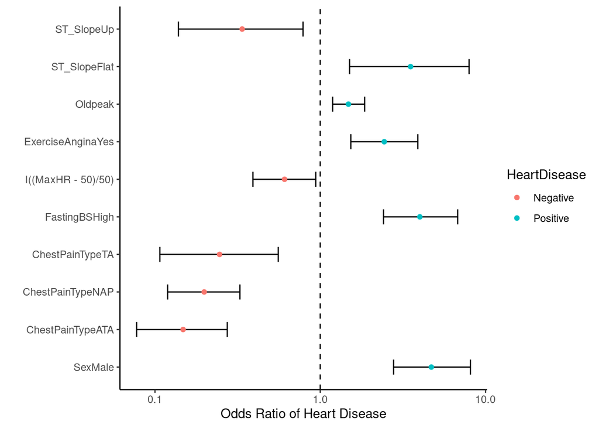

```r
boundaries <- exp(boundaries)
boundaries$HeartDisease <- recode(factor(boundaries$estimate >= 1),"FALSE" = "Negative","TRUE" = "Positive")
boundaries$vnames <- factor(rownames(boundaries),levels= c("SexMale","ChestPainTypeATA","ChestPainTypeNAP","ChestPainTypeTA",
                            "FastingBSHigh","I((MaxHR - 50)/50)","ExerciseAnginaYes","Oldpeak","ST_SlopeFlat","ST_SlopeUp"))
ggplot(boundaries,aes(x = estimate,y = vnames)) +
  ## Add dashed vline at center
  geom_vline(aes(xintercept = 1),linetype = "dashed") +
  ## Add error bars
  geom_errorbarh(aes(xmax = upper,xmin = lower),height = 0.4) +
  ## Add estimates, colour coded based on side of line
  geom_point(aes(colour = HeartDisease)) +
  ## Set theme to classic (nicer background)
  theme_classic() +
  ## Add axis labels
  xlab("Odds Ratio of Heart Disease") +
  ylab("") +
  ## Scale x-axis logarithmicaly
  scale_x_log10()
```

This plot shows how the odds of heard disease change as a result of changes from the baseline. For example, going from an ST_Slope of Down to Up has a negative odds ratio of 0.34, meaning that your odds (or chance) of heart disease decreases by 66%, although the confidence interval for this is relatively high. The error bars show the confidence interval for the odds ratio, and as all factors in the model are deemed significant (at power level of 5%) none of the bars overlap with 1.0. The closest to doing so is MaxHR, which had the largest p-value in the final model. The MaxHR was transformed to make it look clearer on this plot. Subtracting 50 makes a MaxHR of 50 [bpm] the baseline, whilst dividing by 50 makes a single unit increase in the model correspond to a 50 unit increase in your MaxHR. Looking at this plot, a 50 bpm in crease in your MaxHR doesn’t reduce your chance of heart disease as much as having an Up ST_Slope.

## 3.2 Performance

### 3.2.1 Diagnostic Plots

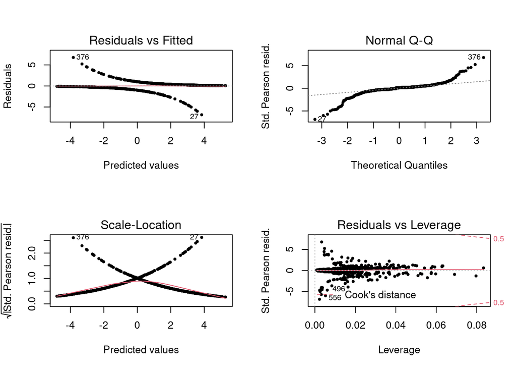

```r
## Diagnostic plots for the glm model
par(mfrow = c(2,2))
plot(lmod3,cex = 0.5,pch = 19,id.n = 2)
```

With binary logistic regression, the diagnostic plots look rather strange as the predictive variable is either 0 or 1, hence the two distinctive curves in the plots on the left. For the residuals vs fitted values plot, we see the tails of the curves having the largest residuals, this is where the model predicted a particular outcome with a large probability however was wrong. Data 27 and 376 are also seen on the scale-location plot, which shows a bulge in the center around 0. All points predicted around 0 are those for which the model doesn’t predict any class distinctly and so always has a reasonable error, this can also be seen in the white space around 0 in the residuals vs fitted plot above. The Q-Q plot shows that the residuals are not normally distributed about the tails, with large over and under predictions for extremities and reasonably normal residuals for values in the inter-quartile range. Lastly the residuals vs leverage plot shows that no datum in particular has a very large leverage on the model that significantly sways the model.

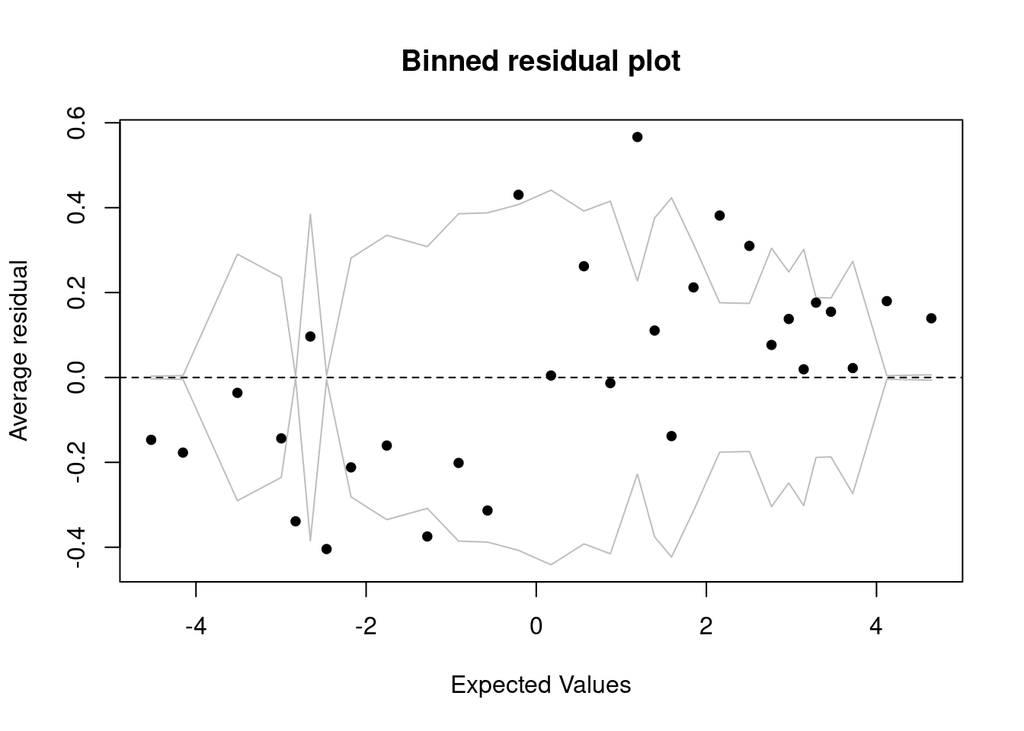

```r
library(arm)
binnedplot(predict(lmod3),resid(lmod3))
```

The binned residual plot is a much more informative version of the first residual plot. There are some points that reside outside the 95% CI, and in places there are is a slight positive correlation in the bins. From this, there is some evidence of non-linearity - the average residual is negative (meaning falsely predicting no Heart Disease) for many values around -2, yet mostly positive above 2.

### 3.2.2 Probability Plot

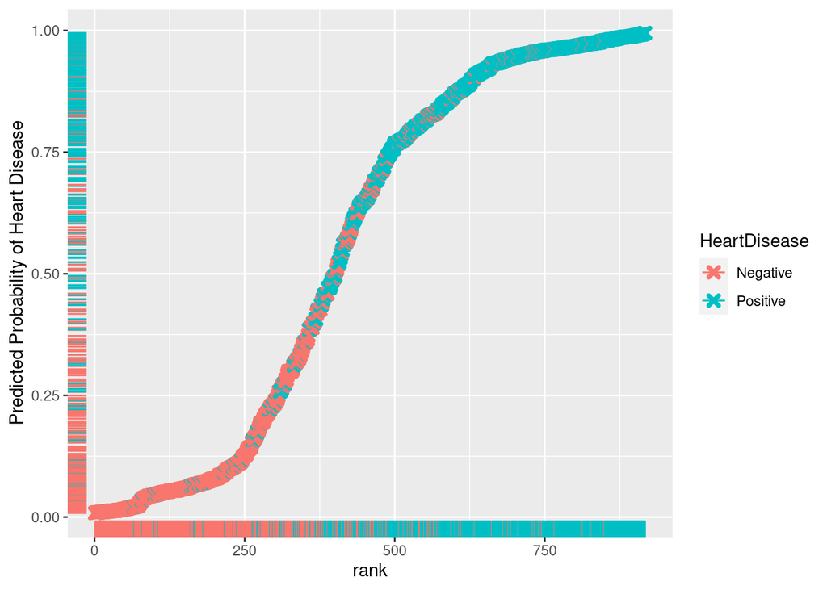

```r
predicted <- data.frame(prob_hd = lmod3$fitted.values,HeartDisease = data$HeartDisease)
predicted <- predicted[order(predicted$prob_hd,decreasing = FALSE),]
predicted$rank <- 1:nrow(predicted)
ggplot(data = predicted,aes(x = rank,y = prob_hd,color = HeartDisease)) + geom_point(alpha = 1,shape = 4,stroke = 2) + geom_rug() + ylab("Predicted Probability of Heart Disease")
```

This graph plots the probability of heart disease, as given by the final model, for each sample against the order of that probability. Values with middling probabilities are predictions where the model isn’t sure what to predict, and so understandably there is a larger amount of missclassification. Values the model is confident in predicting are at the tails, and being monochromatic indicates that the classification accuracy for the tails are expectedly high.

### 3.2.3 ROC Curve

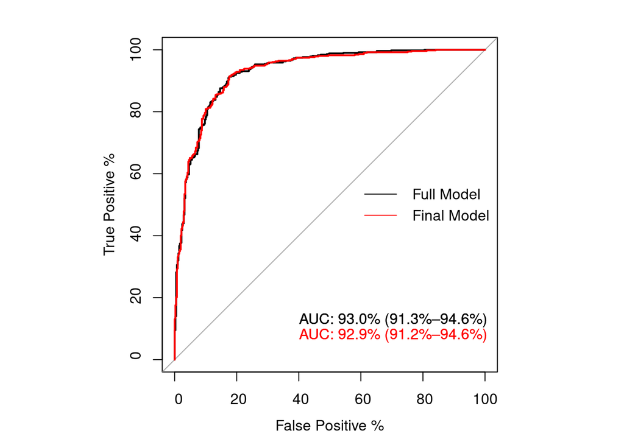

```r
par(pty = "s")
roc_plot <- roc(data$HeartDisease,lmod_full$fitted.values,plot = TRUE,legacy.axes = TRUE,percent = TRUE,xlab = "False Positive %", ylab = "True Positive %",print.auc = TRUE,ci = TRUE,print.auc.y = 15,print.auc.x = 60,ret = TRUE)
roc_plot <- roc(data$HeartDisease,lmod3$fitted.values,plot = TRUE,legacy.axes = TRUE,percent = TRUE,add = TRUE,alp = 0.25,col = "red",ci = TRUE,alpha = 0.2,print.auc = TRUE,print.auc.y = 10,print.auc.x = 60)
legend("right",c("Full Model","Final Model"),col = c("black","red"),lty = 1, bty = "n")
```

```r
## Find optimal threshold value
roc_df <- data.frame(cbind(roc_plot$thresholds,roc_plot$sensitivities,roc_plot$specificities))
optimal_roc_index = which.max(roc_df$X2 + roc_df$X3)
optimal_roc <- roc_df$X1[optimal_roc_index]
sens <- roc_df$X2[optimal_roc_index]
spec <- roc_df$X3[optimal_roc_index]
c(optimal_roc,sens,spec)
```

```
## [1]  0.4557379 91.3214990 82.4390244
```

Comparing the two plots, we see no discernable difference between the first and last model, with very similar ROC curves and AUC’s. The high AUC values show that the model does a good job in classification, managing to achieve a high true positive and low false positive rate across a range of different thresholds. The optimal threshold value is chosen to be that which maximized the sum of Specificity % and Sensitivity %. ### Confusion matrix

```r
preds <- recode(as.factor(predict(lmod3,data,type = "response") >= optimal_roc),"FALSE" = "Negative","TRUE" = "Positive")
true <- factor(data$HeartDisease)
library(caret)
confusionMatrix(preds,true)
```

```
## Confusion Matrix and Statistics
##
##           Reference
## Prediction Negative Positive
##   Negative      338       44
##   Positive       72      463
##
##                Accuracy : 0.8735
##                  95% CI : (0.8502, 0.8943)
##     No Information Rate : 0.5529
##     P-Value [Acc > NIR] : < 2e-16
##
##                   Kappa : 0.7425
##
##  Mcnemar's Test P-Value : 0.01218
##
##             Sensitivity : 0.8244
##             Specificity : 0.9132
##          Pos Pred Value : 0.8848
##          Neg Pred Value : 0.8654
##              Prevalence : 0.4471
##          Detection Rate : 0.3686
##    Detection Prevalence : 0.4166
##       Balanced Accuracy : 0.8688
##
##        'Positive' Class : Negative
##
```

# 4 Stepwise Methods

Mentioned earlier, added for completeness.

```r
Intercept_model = glm(HeartDisease ~ 1,data = data,family = binomial(link = 'logit'))
Full_model = glm(HeartDisease ~ .,data = data,family = binomial(link = 'logit'))
FWD_model = step(Intercept_model,direction = 'forward',trace = 0,scope = formula(Full_model))
BWD_model = step(Full_model,direction = 'backward',trace = 0)
Both_Intercept_model = step(Full_model,direction = 'both',trace = 0,scope = formula(Full_model))
Both_Full_model = step(Full_model,direction = 'both',trace = 0,scope = formula(Full_model))
```